# Project Python Foundations: FoodHub Data Analysis

**Marks: 40**

### Context

The number of restaurants in New York is increasing day by day. Lots of students and busy professionals rely on those restaurants due to their hectic lifestyles. Online food delivery service is a great option for them. It provides them with good food from their favorite restaurants. A food aggregator company FoodHub offers access to multiple restaurants through a single smartphone app.

The app allows the restaurants to receive a direct online order from a customer. The app assigns a delivery person from the company to pick up the order after it is confirmed by the restaurant. The delivery person then uses the map to reach the restaurant and waits for the food package. Once the food package is handed over to the delivery person, he/she confirms the pick-up in the app and travels to the customer's location to deliver the food. The delivery person confirms the drop-off in the app after delivering the food package to the customer. The customer can rate the order in the app. The food aggregator earns money by collecting a fixed margin of the delivery order from the restaurants.

### Objective

The food aggregator company has stored the data of the different orders made by the registered customers in their online portal. They want to analyze the data to get a fair idea about the demand of different restaurants which will help them in enhancing their customer experience. Suppose you are hired as a Data Scientist in this company and the Data Science team has shared some of the key questions that need to be answered. Perform the data analysis to find answers to these questions that will help the company to improve the business.

### Data Description

The data contains the different data related to a food order. The detailed data dictionary is given below.

### Data Dictionary

- order_id: Unique ID of the order
- customer_id: ID of the customer who ordered the food
- restaurant_name: Name of the restaurant
- cuisine_type: Cuisine ordered by the customer
- cost: Cost of the order
- day_of_the_week: Indicates whether the order is placed on a weekday or weekend (The weekday is from Monday to Friday and the weekend is Saturday and Sunday)
- rating: Rating given by the customer out of 5
- food_preparation_time: Time (in minutes) taken by the restaurant to prepare the food. This is calculated by taking the difference between the timestamps of the restaurant's order confirmation and the delivery person's pick-up confirmation.
- delivery_time: Time (in minutes) taken by the delivery person to deliver the food package. This is calculated by taking the difference between the timestamps of the delivery person's pick-up confirmation and drop-off information

### Let us start by importing the required libraries

```python
import warnings
warnings.filterwarnings('ignore') # Library will suppress warnings or deprecation notes
```

```python
# import libraries for data manipulation
import numpy as np
import pandas as pd

# import libraries for data visualization
import matplotlib.pyplot as plt
import seaborn as sns
from sklearn.preprocessing import LabelEncoder #added this library to
```

```python
# for font styling
class color:
    GREEN = '\033[92m'
    BOLD = '\033[1m'
    END = '\033[0m'
```

### Understanding the structure of the data

```python
# read the data
df = pd.read_csv('foodhub_order.csv')
# returns the first 5 rows
df.head()
```

|  | order_id | customer_id | restaurant_name | cuisine_type | cost_of_the_order | day_of_the_week | rating | food_preparation_time | delivery_time |
| --- | --- | --- | --- | --- | --- | --- | --- | --- | --- |
| 0 | 1477147 | 337525 | Hangawi | Korean | 30.75 | Weekend | Not given | 25 | 20 |
| 1 | 1477685 | 358141 | Blue Ribbon Sushi Izakaya | Japanese | 12.08 | Weekend | Not given | 25 | 23 |
| 2 | 1477070 | 66393 | Cafe Habana | Mexican | 12.23 | Weekday | 5 | 23 | 28 |
| 3 | 1477334 | 106968 | Blue Ribbon Fried Chicken | American | 29.20 | Weekend | 3 | 25 | 15 |
| 4 | 1478249 | 76942 | Dirty Bird to Go | American | 11.59 | Weekday | 4 | 25 | 24 |

```python
# Keeping a clone of original dataframe df to prevent any changes in original data structure.
df1= df.copy()
df1.shape
```

```
(1898, 9)
```

#### Observations:

The DataFrame has 9 columns as mentioned in the Data Dictionary. Data in each row corresponds to the order placed by a customer.

### **Question 1:** Write the code to check the shape of the dataset and write your observations based on that. (0.5 mark)

```python
df1.shape
```

```
(1898, 9)
```

#### Observations:

$\color{green}{\text{It appears that there are 1,898 rows and 9 columns available in the given dataset.}}$

### Question 2: Write the observations based on the below output from the info() method. (0.5 mark)

```python
# use info() to print a concise summary of the DataFrame
df1.info()
```

```
<class 'pandas.core.frame.DataFrame'>
RangeIndex: 1898 entries, 0 to 1897
Data columns (total 9 columns):
 #   Column                 Non-Null Count  Dtype
---  ------                 --------------  -----
 0   order_id               1898 non-null   int64
 1   customer_id            1898 non-null   int64
 2   restaurant_name        1898 non-null   object
 3   cuisine_type           1898 non-null   object
 4   cost_of_the_order      1898 non-null   float64
 5   day_of_the_week        1898 non-null   object
 6   rating                 1898 non-null   object
 7   food_preparation_time  1898 non-null   int64
 8   delivery_time          1898 non-null   int64
dtypes: float64(1), int64(4), object(4)
memory usage: 133.6+ KB
```

```python
df1.info()
```

```
<class 'pandas.core.frame.DataFrame'>
RangeIndex: 1898 entries, 0 to 1897
Data columns (total 9 columns):
 #   Column                 Non-Null Count  Dtype
---  ------                 --------------  -----
 0   order_id               1898 non-null   int64
 1   customer_id            1898 non-null   int64
 2   restaurant_name        1898 non-null   object
 3   cuisine_type           1898 non-null   object
 4   cost_of_the_order      1898 non-null   float64
 5   day_of_the_week        1898 non-null   object
 6   rating                 1898 non-null   object
 7   food_preparation_time  1898 non-null   int64
 8   delivery_time          1898 non-null   int64
dtypes: float64(1), int64(4), object(4)
memory usage: 133.6+ KB
```

```python
df1.restaurant_name.value_counts().nunique
```

```
<bound method IndexOpsMixin.nunique of Shake Shack                  219
The Meatball Shop            132
Blue Ribbon Sushi            119
Blue Ribbon Fried Chicken     96
Parm                          68
                            ...
Klong                          1
Kambi Ramen House              1
Il Bambino                     1
Hunan Manor                    1
Lamarca Pasta                  1
Name: restaurant_name, Length: 178, dtype: int64>
```

#### Observations:

$\color{green}{\text{* Understanding of data types available in the dataset is very useful. It determines what values and operation it can perform. It appears that given dataset consists of 3 different types of data types i.e. int64, object & float64.}}$

$\color{green}{\text{* All columns have 1898 observations and it also appears that there is no missing values in the dataset.}}$

$\color{green}{\text{*restaurant_name, cuisine_type and food_preparation_time should be categorical variables.}}$

### Question 3: 'restaurant_name', 'cuisine_type', 'day_of_the_week' are object types. Write the code to convert the mentioned features to 'category' and write your observations on the same. (0.5 mark)

```python
# coverting "objects" to "category" reduces the data space required to store the dataframe
# To convert 'restaurant_name', 'cuisine_type', 'day_of_the_week' into categorical data
# This is useful for model building

df1['restaurant_name'] = df1.restaurant_name.astype('category')
df1['cuisine_type'] = df1.cuisine_type.astype('category')
df1['day_of_the_week'] = df1.day_of_the_week.astype('category')

df1.info()
```

```
<class 'pandas.core.frame.DataFrame'>
RangeIndex: 1898 entries, 0 to 1897
Data columns (total 9 columns):
 #   Column                 Non-Null Count  Dtype
---  ------                 --------------  -----
 0   order_id               1898 non-null   int64
 1   customer_id            1898 non-null   int64
 2   restaurant_name        1898 non-null   category
 3   cuisine_type           1898 non-null   category
 4   cost_of_the_order      1898 non-null   float64
 5   day_of_the_week        1898 non-null   category
 6   rating                 1898 non-null   object
 7   food_preparation_time  1898 non-null   int64
 8   delivery_time          1898 non-null   int64
dtypes: category(3), float64(1), int64(4), object(1)
memory usage: 102.7+ KB
```

#### Observations:

$\color{green}{\text{* By converting 'object' to 'category' we have reduced the usage of data space from 133.6+ KB to 102.7+ KB.}}$

$\color{green}{\text{* The data type of 3 'restaurant_name', 'cuisine_type' and 'day_of_the_week' have been changed from object to category using astype() funtion.}}$

### **Question 4:** Write the code to find the summary statistics and write your observations based on that. (1 mark)

```python
df1.describe(include='all').T
```

|  | count | unique | top | freq | mean | std | min | 25% | 50% | 75% | max |
| --- | --- | --- | --- | --- | --- | --- | --- | --- | --- | --- | --- |
| order_id | 1898.0 | NaN | NaN | NaN | 1477495.5 | 548.049724 | 1476547.0 | 1477021.25 | 1477495.5 | 1477969.75 | 1478444.0 |
| customer_id | 1898.0 | NaN | NaN | NaN | 171168.478398 | 113698.139743 | 1311.0 | 77787.75 | 128600.0 | 270525.0 | 405334.0 |
| restaurant_name | 1898 | 178 | Shake Shack | 219 | NaN | NaN | NaN | NaN | NaN | NaN | NaN |
| cuisine_type | 1898 | 14 | American | 584 | NaN | NaN | NaN | NaN | NaN | NaN | NaN |
| cost_of_the_order | 1898.0 | NaN | NaN | NaN | 16.498851 | 7.483812 | 4.47 | 12.08 | 14.14 | 22.2975 | 35.41 |
| day_of_the_week | 1898 | 2 | Weekend | 1351 | NaN | NaN | NaN | NaN | NaN | NaN | NaN |
| rating | 1898 | 4 | Not given | 736 | NaN | NaN | NaN | NaN | NaN | NaN | NaN |
| food_preparation_time | 1898.0 | NaN | NaN | NaN | 27.37197 | 4.632481 | 20.0 | 23.0 | 27.0 | 31.0 | 35.0 |
| delivery_time | 1898.0 | NaN | NaN | NaN | 24.161749 | 4.972637 | 15.0 | 20.0 | 25.0 | 28.0 | 33.0 |

#### Observations:

$\color{green}{\text{* Using describe() we got the important statistical information of the dataset. To visualize better I transposed the result view.}}$

$\color{green}{\text{* Shake Shack seems to be the most popular restaurant as it has delivered most of the orders.}}$

$\color{green}{\text{* The most preferred cuisine type is American.}}$

$\color{green}{\text{* The average cost per order is 16.49 dollars.}}$

$\color{green}{\text{* Average food preparation time is 27.37 mins.}}$

$\color{green}{\text{* Average delivery time is 24.16 mins.}}$

### **Question 5:** How many orders are not rated? (0.5 mark)

```python
Not_Rated=df1[df1['rating']=='Not given'] # Exctracting Not given values from rating column.
Not_Rated=Not_Rated['rating'].value_counts() # Value Count of Not given.
print('The number of orders which are not rated: ', Not_Rated)
```

```
The number of orders which are not rated:  Not given    736
Name: rating, dtype: int64
```

```python
df['rating'].value_counts(1)
```

```
Not given    0.387777
5            0.309800
4            0.203372
3            0.099052
Name: rating, dtype: float64
```

We can find the percentage of the field by adding 1 in the value count sum

### Exploratory Data Analysis (EDA)

### **Question 6:** Explore all the variables and provide observations on the distributions of all the relevant variables in the dataset. (5 marks)

```python
#data preparation for visualization
#transform dtypes from category/object to int/floats and add them as new variables in the dataset
df2 = df1.copy()
le = LabelEncoder()
df2["cuisine_type_int"] = le.fit_transform(df1["cuisine_type"])
df2["day_of_the_week_int"] = le.fit_transform(df1["day_of_the_week"])

#handling rating category
df2['rating_f'] = df1['rating']

#Replacing 'Not given' by nan values under rating variable
df2.replace(to_replace={"rating_f": {'Not given': np.NaN}},
           inplace=True)

#converting dtype for rating from object to float
df2['rating_f'] = pd.to_numeric(df2['rating_f']) # covert object to
df2['customer_id'] = df2.customer_id.astype('category')
df2.info()
```

```
<class 'pandas.core.frame.DataFrame'>
RangeIndex: 1898 entries, 0 to 1897
Data columns (total 12 columns):
 #   Column                 Non-Null Count  Dtype
---  ------                 --------------  -----
 0   order_id               1898 non-null   int64
 1   customer_id            1898 non-null   category
 2   restaurant_name        1898 non-null   category
 3   cuisine_type           1898 non-null   category
 4   cost_of_the_order      1898 non-null   float64
 5   day_of_the_week        1898 non-null   category
 6   rating                 1898 non-null   object
 7   food_preparation_time  1898 non-null   int64
 8   delivery_time          1898 non-null   int64
 9   cuisine_type_int       1898 non-null   int32
 10  day_of_the_week_int    1898 non-null   int32
 11  rating_f               1162 non-null   float64
dtypes: category(4), float64(2), int32(2), int64(3), object(1)
memory usage: 162.9+ KB
```

```python
#Splitted the df2 dataframe into two new dataframes to group categorical and numerical variables together
# cat_vars = df2['restaurant_name','cuisine_type','cost_of_the_order','day_of_the_week','rating']                 1898 non-null   object
cat_vars = df2.drop(columns=['customer_id','cost_of_the_order','food_preparation_time','delivery_time','cuisine_type_int','day_of_the_week_int','rating_f'])
# cat_vars
num_vars = df2.drop(columns=['order_id', 'customer_id','restaurant_name','rating','cuisine_type','day_of_the_week'])
# num_vars
```

```python
def histogram_boxplot(data, feature, figsize=(12, 7), kde=False, bins=None):
    """
    Boxplot and histogram combined

    data: dataframe
    feature: dataframe column
    figsize: size of figure (default (12,7))
    kde: whether to show the density curve (default False)
    bins: number of bins for histogram (default None)
    """
    f2, (ax_box2, ax_hist2) = plt.subplots(
        nrows=2,  # Number of rows of the subplot grid= 2
        sharex=True,  # x-axis will be shared among all subplots
        gridspec_kw={"height_ratios": (0.25, 0.75)},
        figsize=figsize,
    )  # creating the 2 subplots
    sns.boxplot(
        data=data, x=feature, ax=ax_box2, showmeans=True, color="violet"
    )  # boxplot will be created and a star will indicate the mean value of the column
    sns.histplot(
        data=data, x=feature, kde=kde, ax=ax_hist2, bins=bins, palette="winter"
    ) if bins else sns.histplot(
        data=data, x=feature, kde=kde, ax=ax_hist2
    )  # For histogram
    ax_hist2.axvline(
        data[feature].mean(), color="green", linestyle="--"
    )  # Add mean to the histogram
    ax_hist2.axvline(
        data[feature].median(), color="black", linestyle="-"
    )  # Add median to the histogram
```

```python
df['order_id'].nunique()
```

```
1898
```

#### Food preparation time analysis

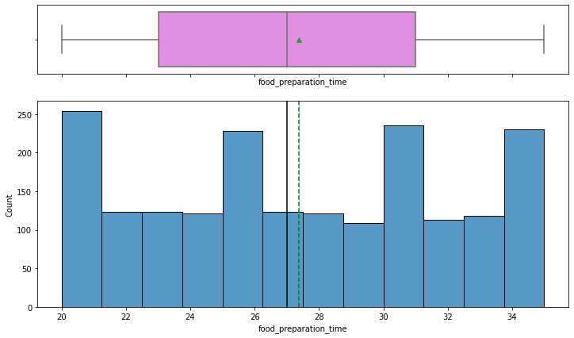

```python
histogram_boxplot(df2, 'food_preparation_time')
```

### Observations

- The distribution of Food Preparation time looks almost Symmetrical.
- Median of the food preparation time is 27 and Mean is around 27.4.
- There are no of outliers in this variable.
- Maximum Orders are for the for the lowest Food preparation time.

##### Delivery time analysis

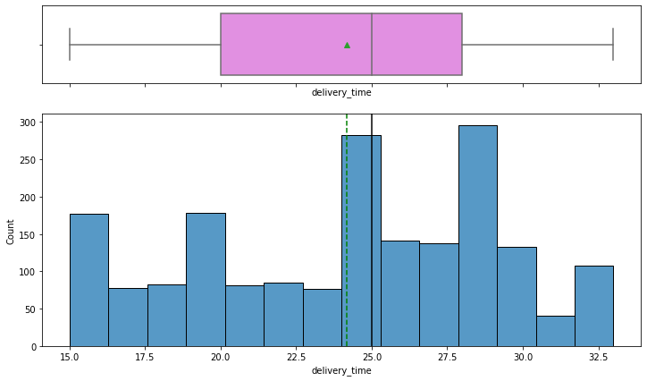

```python
histogram_boxplot(df2, 'delivery_time')
```

### Observation

- The distribution of Food delivery time looks negatively skewed.
- Median of the food delivery time is 25 minutes and Mean is around 24 minutes.
- There are no outliers in this variable.

##### Cost per order analysis

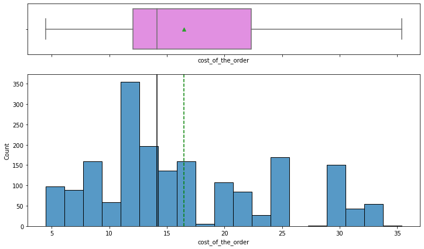

```python
histogram_boxplot(df2, 'cost_of_the_order')
```

### Observation

- The above histogram of cost of the order is right skewed.
- Orders are slightly higher when the cost of the order is lower.
- Median cost of the order is around 14.14 and the mean is around 16.5.
- There are no outliers in this variable.
- While most cost of the oredrs are slightly higher when the cost is low, we have observations where the orders went as high as 350 when the cost of the order was between $11-$12.

##### Customer rating analysis

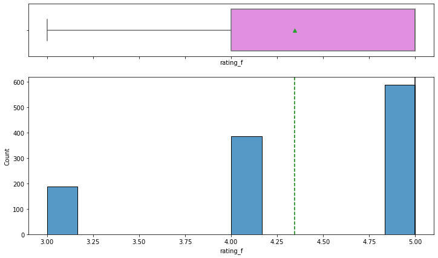

```python
histogram_boxplot(df2, 'rating_f')
```

### Observation

- The above distribution boxplot of rating seems to be left skewed, as the maximum number of orders are not rated most of the times.
- Median of the rating is at 5 and mean is around 4.35.
- There are no outliers visible currently in this variable.
- After Not rating, 5 has been given the second highest numbers by the cusomers.

##### Cuisine type analysis

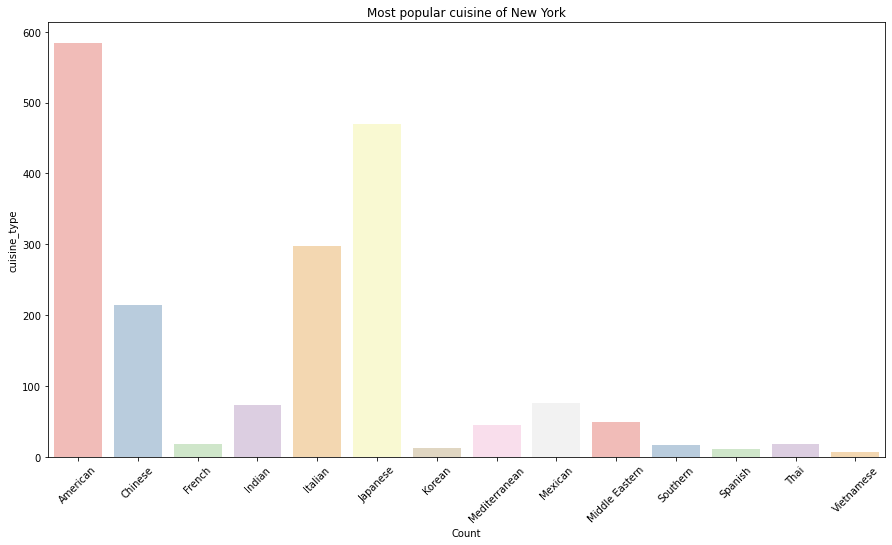

```python
plt.figure(figsize=(15,8))
cuis_type=df2['cuisine_type'].value_counts()
sns.barplot(cuis_type.index,cuis_type,palette='Pastel1')
plt.xlabel('Count')
plt.title("Most popular cuisine of New York")
plt.xticks(rotation=45);
```

### Observation

- The above bar plot clearly indicates that American is the most popular cuine of New York, followed by Japanese, Italian and Chinese
- Median of the rating is at 5 and mean is around 4.35.
- Rest of the cusine types are hardly orderd in New York.

##### Orders trend over week analysis

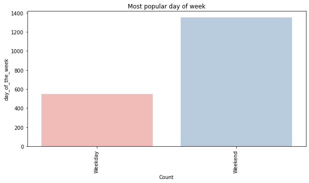

```python
plt.figure(figsize=(10,5))
dow=df2['day_of_the_week'].value_counts()
sns.barplot(dow.index,dow,palette='Pastel1')
plt.xlabel('Count')
plt.title("Most popular day of week")
plt.xticks(rotation=90);
```

### Observation

- The above observation clearly states that count of order for Foodhub is maximum on Weekends i.e. above 71% of the total oredrs

### Question 7: Write the code to find the top 5 restaurants that have received the highest number of orders. (1 mark)

```python
df1['restaurant_name'].value_counts().sort_values(ascending=False).head(5) # sorting the value count of the orders for the top 5 restaurants
```

```
Shake Shack                  219
The Meatball Shop            132
Blue Ribbon Sushi            119
Blue Ribbon Fried Chicken     96
Parm                          68
Name: restaurant_name, dtype: int64
```

#### Observations:

$\color{green}{\text{ It appears Restaurant name - Shake Shack has received most of the orders i.e. 219 followed by The Meatball Shop with 132 orders and Blue Ribbon Sushi with 119 orders. Shake Shack offers American cuisines and we observed earlier also, that is the most popular cuisine among FoodHub customers.}}$

### Question 8: Write the code to find the most popular cuisine on weekends. (1 mark)

```python
#most popular cuisine
popular_cuisine = df1[df1['day_of_the_week'] == 'Weekend'] # considering only weekend from the day of the week
popular_cuisine = popular_cuisine['cuisine_type'].value_counts().sort_values(ascending=False).head(1) # picking the top cusine type only on weekends
print('The most popular cuisine on Weekends is :\n', popular_cuisine)
```

```
The most popular cuisine on Weekends is :
 American    415
Name: cuisine_type, dtype: int64
```

```python
popular_cuisine = df1[df1['day_of_the_week'] == 'Weekend']
popular_cuisine = popular_cuisine['cuisine_type'].value_counts().sort_values(ascending=False).head(1)
print('The most popular cuisine on Weekends is :\n', popular_cuisine)
```

```
The most popular cuisine on Weekends is :
 American    415
Name: cuisine_type, dtype: int64
```

#### Observations:

$\color{green}{\text{ The most popular cuisine on weekends is American as the frequency of American Cuisine type is the highest i.e 415.}}$

### Question 9: Write the code to find the number of total orders where the cost is above 20 dollars. What is the percentage of such orders in the dataset? (1 mark)

```python
Order = df1[df1['cost_of_the_order'] > 20] # choosing orders above $ 20
Total_Order_abv20 = Order.value_counts().sum() # counting the orders above $20 and adding the adding the same.
Total_Order_Records = df1['cost_of_the_order'].count().sum()
Percentage = (Total_Order_abv20/Total_Order_Records)*100 # percentage of the order
Percentage = f'{Percentage:.2f}' # number formating rounding upto 2 decimals

print('The number of total orders where the cost is above 20 dollars is:', Total_Order_abv20)
print()
print('The percentage of orders above 20 dollars in the dataset is:', Percentage, '%')
```

```
The number of total orders where the cost is above 20 dollars is: 555

The percentage of orders above 20 dollars in the dataset is: 29.24 %
```

### Question 10: Write the code to find the mean delivery time based on this dataset. (1 mark)

```python
DT= df1['delivery_time'].mean() # average of the delivery time
DT = f'{DT:.2f}' # number formating rounding upto 2 decimals
print('The mean delivery time based on this dataset is:', DT)
```

```
The mean delivery time based on this dataset is: 24.16
```

### Question 11: Suppose the company has decided to give a free coupon of 15 dollars to the customer who has spent the maximum amount on a single order. Write the code to find the ID of the customer along with the order details. (1 mark)

```python
Max_Single_Order = df1['cost_of_the_order'].max()
print()
print(color.BOLD + color.GREEN + 'The maximum amount spent on a single order is: $'+ color.END, Max_Single_Order )
print()
print(color.BOLD + color.GREEN + 'The ID of the customer along with the order details are below:\n' + color.END, df.loc[573])
```

```
The maximum amount spent on a single order is: $ 35.41

The ID of the customer along with the order details are below:
 order_id                       1477814
customer_id                      62359
restaurant_name                  Pylos
cuisine_type             Mediterranean
cost_of_the_order                35.41
day_of_the_week                Weekday
rating                               4
food_preparation_time               21
delivery_time                       29
Name: 573, dtype: object
```

#### Observations:

$\color{green}{\text{Customer_id 62359 is eligible to receive the free coupon of 15 dollars as he/she is the one who spent the maximum on one single order in the given dataset. He/she ordered Mediterranean food from Pylos and seems satisfied as he rated 4. However, the delivery time seems to be a bit higher than the average time.}}$

### Question 12: Perform bivariate/multivariate analysis to explore relationships between the important variables in the dataset. (7 marks)

# Correlation

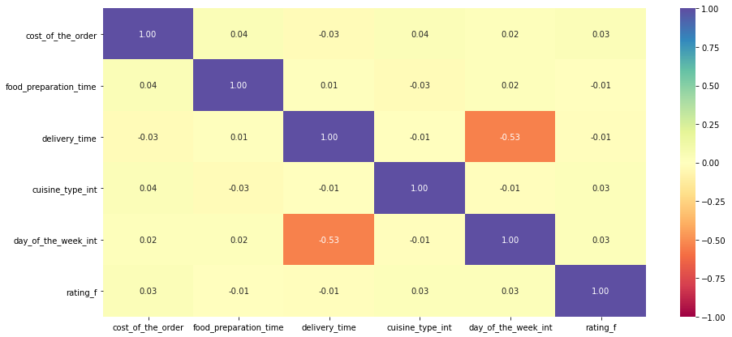

```python
corr = num_vars.corr()

# plot the heatmap

plt.figure(figsize=(15, 7))
sns.heatmap(corr, annot=True, vmin=-1, vmax=1, fmt=".2f", cmap="Spectral", xticklabels=corr.columns, yticklabels=corr.columns)
plt.show()
```

### Observations

- Delivery time is negatively correlated with day of the week. specially on weekdays the delivery becomes slower due to heavy traffic. This is aligned with our intuitive understanding.
- There does not seem to be a strong relationship between any variable.

# Bivariate Scatter Plot

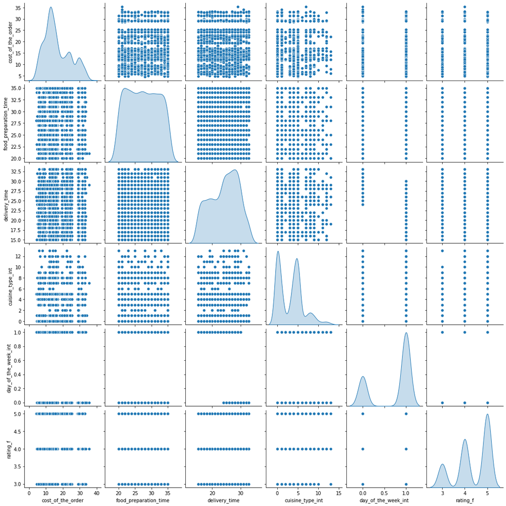

```python
# pairplot
sns.pairplot(data=num_vars, diag_kind="kde")
plt.show()
```

**Observations**

- We get the same insights as from the correlation plot
- There does not seem to be a strong relationship between any variable

### Relationship between Cuisine type and Food preparation time

[figure not shown]

```python
#Pointplot
A = df2.groupby(by=['cuisine_type'])['food_preparation_time'].mean().reset_index().sort_values(['landing_page'])
sns.pointplot(x='cuisine_type', y='food_preparation_time', ci= None, data = A)
plt.xticks(rotation=0)
plt.show()
```

**Observations**

- Korean & Vietnamese cuisine takes relatively lesser preparation time amongst all the cusine type.
- Almost all the other cuisine takes almost similar time for the preparation.

##### Relationship between Restaurants and Order on Weekday and Weekend

```python
#creating a new clone of original dataset
df_new= df.copy()
df_new.head(10)
```

|  | order_id | customer_id | restaurant_name | cuisine_type | cost_of_the_order | day_of_the_week | rating | food_preparation_time | delivery_time |
| --- | --- | --- | --- | --- | --- | --- | --- | --- | --- |
| 0 | 1477147 | 337525 | Hangawi | Korean | 30.75 | Weekend | Not given | 25 | 20 |
| 1 | 1477685 | 358141 | Blue Ribbon Sushi Izakaya | Japanese | 12.08 | Weekend | Not given | 25 | 23 |
| 2 | 1477070 | 66393 | Cafe Habana | Mexican | 12.23 | Weekday | 5 | 23 | 28 |
| 3 | 1477334 | 106968 | Blue Ribbon Fried Chicken | American | 29.20 | Weekend | 3 | 25 | 15 |
| 4 | 1478249 | 76942 | Dirty Bird to Go | American | 11.59 | Weekday | 4 | 25 | 24 |
| 5 | 1477224 | 147468 | Tamarind TriBeCa | Indian | 25.22 | Weekday | 3 | 20 | 24 |
| 6 | 1477894 | 157711 | The Meatball Shop | Italian | 6.07 | Weekend | Not given | 28 | 21 |
| 7 | 1477859 | 89574 | Barbounia | Mediterranean | 5.97 | Weekday | 3 | 33 | 30 |
| 8 | 1477174 | 121706 | Anjappar Chettinad | Indian | 16.44 | Weekday | 5 | 21 | 26 |
| 9 | 1477311 | 39705 | Bukhara Grill | Indian | 7.18 | Weekday | 5 | 29 | 26 |

##### Weekend vs Weekday demand analysis

```python
#Analysisng demand pattern over the week
weekend = df_new[(df_new['day_of_the_week'] == 'Weekend')]
Weekends = weekend['restaurant_name'].count()

Weekends = f"{Weekends:.2f}" #(number formating rounding upto 2 decimals)

weekday = df_new[(df_new['day_of_the_week'] == 'Weekday')]
Weekdays = weekday['restaurant_name'].count()

Weekdays = f"{Weekdays:.2f}"

print('Restaurants busy on weekend :',Weekends)
print('Restaurants busy on weekday :',Weekdays)
```

```
Restaurants busy on weekend : 1351.00
Restaurants busy on weekday : 547.00
```

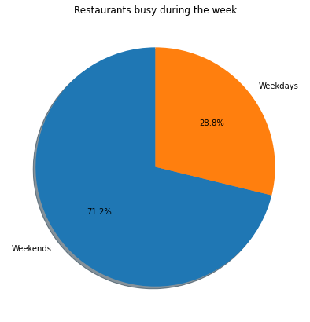

```python
Days_of_the_week= ['Weekends', 'Weekdays']

data = [1351, 547]

# Creating plot
fig = plt.figure(figsize =(10, 7))
plt.pie(data, labels = Days_of_the_week,autopct='%1.1f%%', shadow=True, startangle=90 )
plt.title('Restaurants busy during the week')
# show plot
plt.show()
```

**Observation**

- Majority of the orders for Restaurants are on Weekends

##### Customer Loyalty analysis

```python
#understand single vs repeate customers
df2['customer_id'].value_counts().unique() #unique frequency numbers: 13, 10,  9,  8,  7,  6,  5,  4,  3,  2,  1
rep_cust = (df2.groupby(['customer_id']).agg({'order_id':['count']}))
rep_cust.columns = ['_'.join(col) for col in rep_cust.columns]

unique_cust_count = rep_cust.count() # Total unique customers count is 1200

repeate_cust = rep_cust[rep_cust['order_id_count']> 1]
repeat_cust_count = repeate_cust.count() #416 customers are repeate customers

non_repeate_cust = rep_cust[rep_cust['order_id_count'] == 1]
non_repeate_cust_count = non_repeate_cust.count() #784 customers are single time users
```

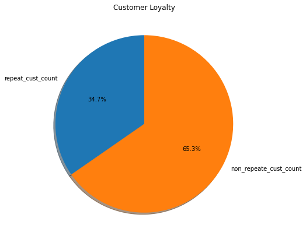

```python
Customer_Loyalty = ['repeat_cust_count', 'non_repeate_cust_count']

data = [416, 784]

# Creating plot
fig = plt.figure(figsize =(10, 7))
plt.pie(data, labels = Customer_Loyalty, autopct='%1.1f%%', shadow=True, startangle=90 )
plt.title('Customer Loyalty')
# show plot
plt.show()
```

**Observations**

- Majority of the customers are just one time buyers on the platform.
- Only 35% of the buyers have made purchase more than once on the platform.

##### Top preferred Cuisine types analysis

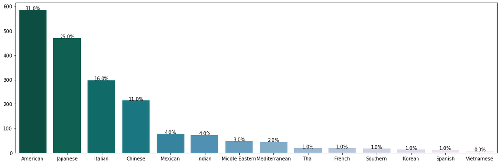

```python
plt.rcParams["figure.figsize"] = [15.00, 5.0]
plt.rcParams["figure.autolayout"] = True


# cuis_type=df2['cuisine_type'].value_counts()
x = ['American', 'Japanese', 'Italian', 'Chinese', 'Mexican', 'Indian', 'Middle Eastern', 'Mediterranean', 'Thai', 'French', 'Southern', 'Korean','Spanish','Vietnamese']
y = [584, 470, 298, 215, 77, 73, 49, 46, 19, 18, 17, 13, 12, 7]
percentage = [31, 25, 16, 11, 4, 4, 3, 2, 1, 1, 1, 1, 1, 0]
ax = sns.barplot(x=x, y=y, palette='PuBuGn_r')
patches = ax.patches
for i in range(len(patches)):
   x = patches[i].get_x() + patches[i].get_width()/2
   y = patches[i].get_height()+.05
   ax.annotate('{:.1f}%'.format(percentage[i]), (x, y), ha='center')
plt.show()
```

### Observation

- The above bar plot indicates that the top 4 cuisines are significantly in demand and it consists of 83% of the overall orders in the given dataset.

##### Restaurant performance analysis

```python
Weekend = df1[(df1['day_of_the_week'] == 'Weekend')]
popular_cuisine = df1[df1['day_of_the_week'] == 'Weekend']
print('The most popular cuisine on weekends is :', popular_cuisine['cuisine_type'].value_counts().sort_values(ascending=False).head(1))

Weekday = df1[(df1['day_of_the_week'] == 'Weekday')]
popular_cuisine = df1[df1['day_of_the_week'] == 'Weekday']
print('The most popular cuisine on weekdays is :', popular_cuisine['cuisine_type'].value_counts().sort_values(ascending=False).head(1))
```

```
The most popular cuisine on weekends is : American    415
Name: cuisine_type, dtype: int64
The most popular cuisine on weekdays is : American    169
Name: cuisine_type, dtype: int64
```

```python
# rex = (df_new.groupby(['restaurant_name'].count[:10]).agg({'cost_of_the_order':['mean'], 'delivery_time':['mean']})) ##Using groupby and agg function
# rex.columns=['_'.join(col) for col in rex.columns]         # To join the results from above group by and aggregated data
# rex.head()
# results=rex[rex['delivery_time_mean']>30] ##Adding the two mentioned conditions
# # results.shape
# plt.figure(figsize=(20,10))
# sns.lineplot(x="restaurant_name", y="delivery_time_mean", ci=95, data=results) #, hue='cost_of_the_order_mean')
# plt.ylabel('Total delivery time')
# plt.xlabel('Cost of the order')
# plt.show()
```

### Question 13: Suppose the company wants to provide a promotional offer in the advertisement of the restaurants. The condition to get the offer is that the restaurants must have a rating count of more than 50 and the average rating should be greater than 4. Write the code to find the restaurants fulfilling the criteria to get the promotional offer. (2 marks)

```python
re = (df2.groupby(['restaurant_name']).agg({'rating_f':['mean', 'count']})) ##Using groupby and agg function
re.columns=['_'.join(col) for col in re.columns]         # To join the results from above group by and aggregated data
result = re[(re['rating_f_count']>50) & (re['rating_f_mean'] >4) ] ##Adding the two mentioned conditions
print(color.BOLD+'Below is the list of restaurants with more than 60 ratings and average mean value greater than 4:'+color.END )
print()
print(result)
```

```
Below is the list of restaurants with more than 60 ratings and average mean value greater than 4:

                           rating_f_mean  rating_f_count
restaurant_name
Blue Ribbon Fried Chicken       4.328125              64
Blue Ribbon Sushi               4.219178              73
Shake Shack                     4.278195             133
The Meatball Shop               4.511905              84
```

```python
re = (df2.groupby(['restaurant_name']).agg({'rating_f':['mean', 'count']}))
re.columns=['_'.join(col) for col in re.columns]
result = re[(re['rating_f_count']>50) & (re['rating_f_mean'] >4) ]
```

```python
df2.info()
```

```
<class 'pandas.core.frame.DataFrame'>
RangeIndex: 1898 entries, 0 to 1897
Data columns (total 12 columns):
 #   Column                 Non-Null Count  Dtype
---  ------                 --------------  -----
 0   order_id               1898 non-null   int64
 1   customer_id            1898 non-null   category
 2   restaurant_name        1898 non-null   category
 3   cuisine_type           1898 non-null   category
 4   cost_of_the_order      1898 non-null   float64
 5   day_of_the_week        1898 non-null   category
 6   rating                 1898 non-null   object
 7   food_preparation_time  1898 non-null   int64
 8   delivery_time          1898 non-null   int64
 9   cuisine_type_int       1898 non-null   int32
 10  day_of_the_week_int    1898 non-null   int32
 11  rating_f               1162 non-null   float64
dtypes: category(4), float64(2), int32(2), int64(3), object(1)
memory usage: 162.9+ KB
```

```python
df.value_counts('restaurant_name').head(5)
```

```
restaurant_name
Shake Shack                  219
The Meatball Shop            132
Blue Ribbon Sushi            119
Blue Ribbon Fried Chicken     96
Parm                          68
dtype: int64
```

```python
df['order_id'].value_count().nunique()
```

[output not shown]

#### Observations:

It appears that there are 4 restaurants (highlighted above) who qualify for the promotional offer as they have received more than 50 ratings and their average mean rating is also above 4.

### Question 14: Suppose the company charges the restaurant 25% on the orders having cost greater than 20 dollars and 15% on the orders having cost greater than 5 dollars. Write the code to find the net revenue generated on all the orders given in the dataset. (2 marks)

```python
#create two new columns to compute % of charges that the company make
rev_25 = df_new[df_new['cost_of_the_order']>20]
df_new['charges_25'] = 0.25* rev_25['cost_of_the_order']

rev_15 = df_new[(df_new['cost_of_the_order'] >5) & (df_new['cost_of_the_order'] <20)]
df_new['charges_15'] = 0.15* rev_15['cost_of_the_order']

#total_revenue = 25% + 15%
total_revenue = df_new['charges_25'].fillna(0) + df_new['charges_15'].fillna(0)
df_new['total_revenue'] = total_revenue

#net revenue generated on all the orders given in the dataset
new_revenue = df_new['total_revenue'].sum()
new_revenue
new_revenue = f"{new_revenue:.2f}"

print(color.BOLD + color.GREEN + 'The net revenue generated by the company on all the orders given in the dataset is:', '$'+color.END, new_revenue)
```

[output not shown]

#### Observations:

- The net revenue generated by the company on all the orders given in the dataset is: $ 6166.30
- Assumed there is no additional cost like cancellation/returns/discounts offered.

### Question 15: Suppose the company wants to analyze the total time required to deliver the food. Write the code to find out the percentage of orders that have more than 60 minutes of total delivery time. (2 marks)

Note: The total delivery time is the summation of the food preparation time and delivery time.

```python
# write the code here
#total_delivery_time = food_preparation_time + delivery_time
sum_column = df_new['food_preparation_time']+df_new['delivery_time']
df_new['total_delivery_time'] = sum_column
df_new.head()
# df_new.shape      #(1898, 13)
```

[output not shown]

```python
# Count number of records with total_delivery_time>60 minutes
# df_new.shape  #returns 1898 orders

moreThanAnHour = df_new[df_new['total_delivery_time'] > 60]
moreThanAnHour_count = moreThanAnHour['total_delivery_time'].value_counts().sum()

print('Count of deliveries with more than 60 minutes: ', moreThanAnHour_count)

# # The percentage of orders that have more than 60 minutes of total delivery time
Percentage_moreThanAnHour = moreThanAnHour_count/1898*100
Percentage_moreThanAnHour = f"{Percentage_moreThanAnHour:.2f}"

print('\nThe percentage of orders that have more than 60 minutes of total delivery time :', Percentage_moreThanAnHour, '%')
```

[output not shown]

#### Observations:

$\color{green}{\text{* First of all created a new column in the dataframe to compute the total delivery time which is a sum of food preparation time and delivery time.}}$ $\color{green}{\text{* Counted the total number of orders with total delivery time more than 60 minutes i.e. 200 and that consists 10.54 percentage of the total orders in the dataset.}}$

### Question 16: Suppose the company wants to analyze the delivery time of the orders on weekdays and weekends. Write the code to find the mean delivery time on weekdays and weekends. Write your observations on the results. (2 marks)

```python
# write the code here
weekend = df_new[(df_new['day_of_the_week'] == 'Weekend')]
delivery_time_weekend = weekend['delivery_time'].mean()
delivery_time_weekend = f"{delivery_time_weekend:.2f}"

weekday = df_new[(df_new['day_of_the_week'] == 'Weekday')]
delivery_time_weekday = weekday['delivery_time'].mean()
delivery_time_weekday = f"{delivery_time_weekday:.2f}"

print('The mean delivery time on weekend :', delivery_time_weekend, 'minutes')
print('The mean delivery time on weekdays :', delivery_time_weekday, 'minutes')
```

[output not shown]

$\color{green}{\text{It appears that the average delivery time on weekdays is greater than the weekend. It could be due to the office hour traffic.}}$

```python
Top_15 = df1['restaurant_name'].value_counts().sort_values(ascending=False).head(15) # sorting the value count of the orders for the top 5 restaurants
print(Top_15)
sum=Top_15.sum()
print()
print('The sum of top 15 restaurants is', sum)
```

[output not shown]

*Observation*

- The sum of Top 15 restaurants contribute 56% of the overall orders.

### Conclusion and Recommendations

### **Question 17:** Write the conclusions and business recommendations derived from the analysis. (3 marks)

## Conclusion:

After analysing the dataset of Foodhub app for New York city,following are the key findings:

1. Order demand for Restaurants is majorily on the weekends i.e.71% in the given dataset.
2. Top 15 restaurants contirbute to 56% of the overall orders and all these restaurants have tieups with the most saleable cuisines of New York.
3. American, Japanese, Italian and chinese cusines majorly rules the New York market with 83% of the market share.
4. The average cost per order 16.5 dollars and median is 14.14 dollars. Volume of the orders is higher when the cost of the order is lower.
5. The average time taken () to deliver the food on weekdays is higher than the weekends.
6. More than 65% of the Customers are only one time customers on the app.
7. Maximum customers on the app have not rated or chose not to rate.

## Recommendation to business

**DRIVE MORE CUSTOMER ORDERS**

- Introduce relevant combo offers to upsell non American/Japaneese/Italian/Chinese cuisines also to increase the demand of other cuisines as well.
- The likelihood of increasing demand of high valued orders can be improved by probably introducing complimentary items like desserts, beverages etc.
- Introduce referral program to increase the new customer base by incentivisng the new customers as well as the referrer.
- Restaurants who receive major orders are the one with a tie up with all the major cuisines, in order to receive more orders, FoodHub should tie up with more restaurants which offers similar cuisines

**INCREASE FOODHUB APP TRAFFIC ON WEEKDAYS**

- Great potential to increase demand throught weekdays by giving promotional offers on the Breakfast/lunch/dinner or introducing weekday special discounts.

**INCREASE CUSTOMER LOYALTY AND SATISFACTION**

- Build Customer retention programs specially for the one time buyers: i. Introduce point value system on the number of orders to get a meal free from Foodhub
- Introduce customer loyalty program: i. Reward for the loyal customers in terms of redemeble reward points, vouchers, complimentary etc. ii. Encourage existing customers to rate every orders they receive by offering reward points.

**INCENTIVIZE DRIVERS TO DELIVER MORE**

- Provide localized incentives to deliveries/day – either by balancing by higher delivery drivers or by adding investment.

**KEY INSIGHTS**

- Additional data will be required to analyse, why majority of the customer have not come for the second time on the platform. Few of the reasons can be as per the following: i. Price issue ii. delivery issue iii. Restaurants tie-ups issue iv. App function issue etc....